# A1 submission

Paballo Sejanamane

2023

### Prelimary steps:

### Question 1:

```r
mean(test_data$Price)
```

```
## [1] 1803401
```

##### The average price of properties sold is R1 803 401

### Question 2

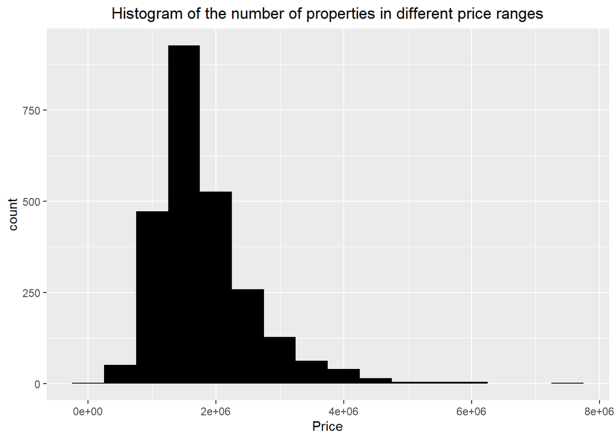

```r
ggplot(test_data, aes(x = Price)) +
  geom_histogram(binwidth = 500000, fill = "black")+  ggtitle("Histogram of the number of properties in different price ranges") + theme(plot.title = element_text(hjust = 0.5))
```

```r
#Citation: https://www.geeksforgeeks.org/how-to-change-position-of-ggplot-title-in-r/
```

### Question 3

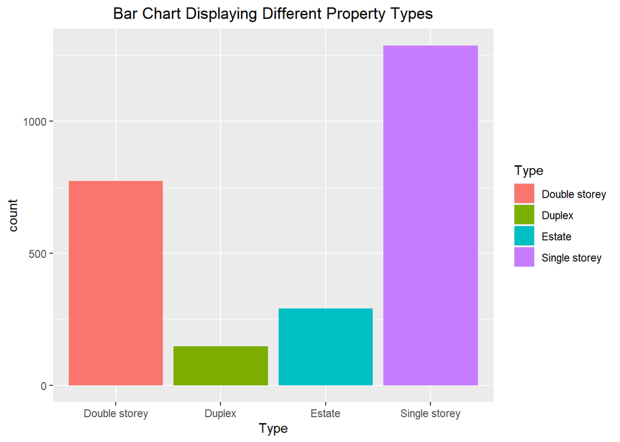

```r
ggplot(test_data, aes(x = Type, fill = Type), ) +
  geom_bar() +ggtitle("Bar Chart Displaying Different Property Types") + theme(plot.title = element_text(hjust = 0.5))
```

##### This bar chart shows that most sold properties are single storey, then double story, then properties in estates then duplexes

### Question 4

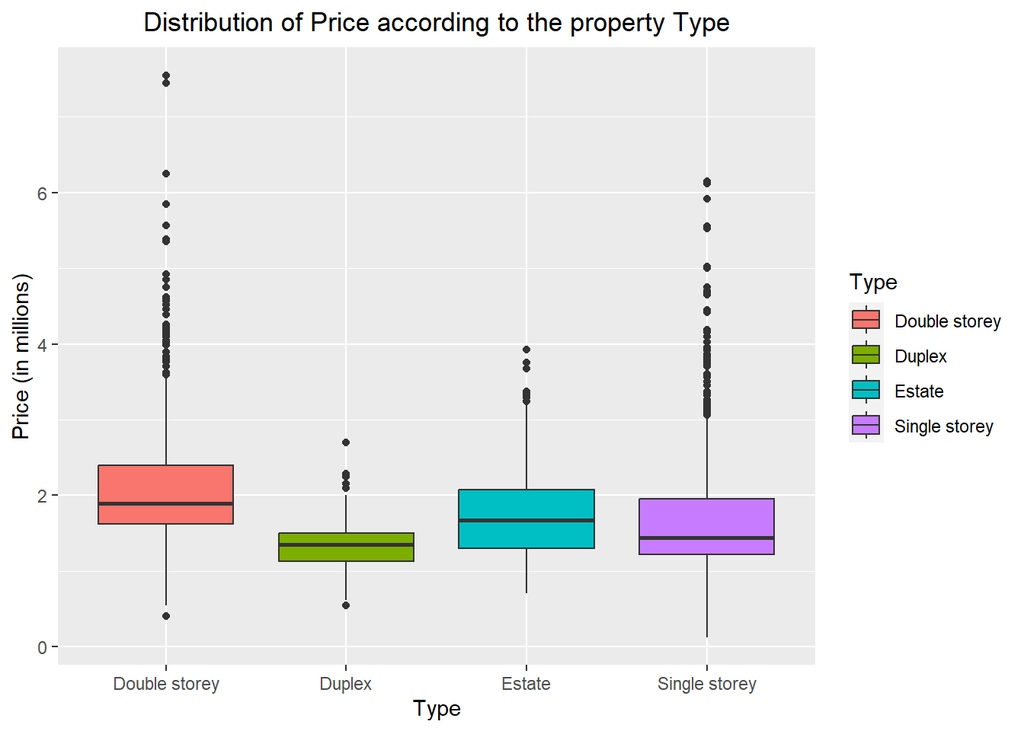

```r
ggplot(test_data, aes(x = Type, y = Price_in_millions, fill = Type)) +
  geom_boxplot() +
  ggtitle("Distribution of Price according to the property Type") +
  ylab("Price (in millions)") +
  theme(plot.title = element_text(hjust = 0.5))
```

```r
## Citation: https://www.statology.org/side-by-side-boxplot-in-r/
```

##### Double storey properties have the highest median price in millions, then estates, then single storey properties, followed by duplexes.

##### This makes some sense as double storey houses are normally quite big, so they would cost more, estate properties often have their own estate maintenance costs and one pays more for security. Finally, single stories may be expensive depending on the area one lives in or the size of the house, which could explain why the data is a bit skewed to the pricier side, but it would not be more than a double storey house. Lastly, duplex properties would be cheapest as there is no security company involved and duplexes are normally smaller in size compared to double storey, single story and properties in estates.

### Question 5

```r
test_data %>%
  group_by(Area) %>%
  summarise(Number_of_properties = n(),
            Average_price_of_properties = mean(Price)) %>%
  arrange(desc(Number_of_properties))
```

```
## # A tibble: 4 × 3
##   Area         Number_of_properties Average_price_of_properties
##   <fct>                       <int>                       <dbl>
## 1 Residential                  2475                    1813591.
## 2 Commercial                     21                     824375.
## 3 Agricultural                    2                     473000
## 4 Industrial                      2                     803125
```

##### Furthermore, the number of properties sold between agricultural areas and industrial areas is the same, but the average price of properties sold in industrial areas is more, this could indicate that the properties in industrial areas are more expensive

### Question 6.1

```r
sum(is.na(test_data$Street_front))
```

```
## [1] 413
```

##### There seems to be 413 missing values in the *Street_front* variable. This is quite a lot for a data set

### Question 6.2

```r
cordata <- na.omit(test_data, cols = "Street_front")
```

### Question 6.3

```r
cor_data <-cor(cordata$Street_front, cordata$Size)
```

```r
round(cor_data, 3)
```

```
## [1] 0.584
```

##### It seems that Street front and Size of property have a moderately strong relationship. Indicating that the bigger the size of the property, the bigger the street front and vice versa

### Question 6.4

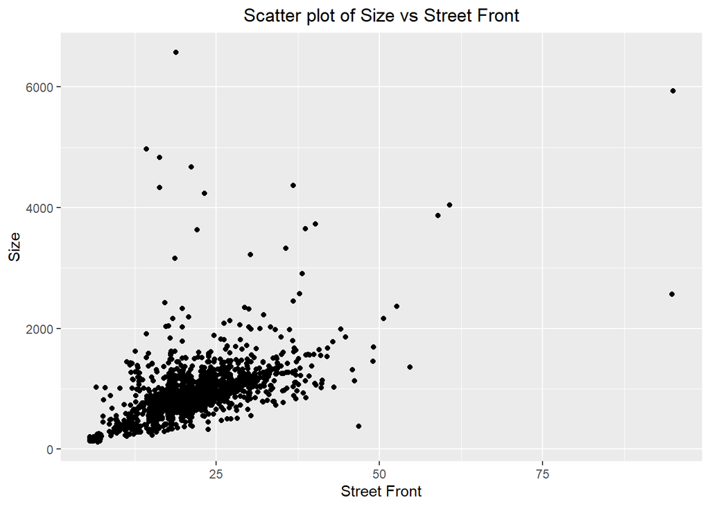

```r
ggplot(data = cordata, aes(x = Street_front, y = Size)) +
  geom_point(position = "jitter") +
  labs(x = "Street Front", y = "Size", title = "Scatter plot of Size vs Street Front") + theme ( plot.title = element_text(hjust = 0.5))
```

##### There are a few outliers present for size front and for the size of property.

##### Specifically with size that go above 3000 and street fronts above 40. I would opt to replace the outliers with more values within a certain range, for example, values over 50 for Street Fronts, would be set to 50. A similar approach would be taken for the size of the property.

##### An extreme case would be to remove the outliers as a whole but this would also result in a loss of information. It just depends whether, the agency is interested in knowing if the size of the plot and the street front result in a sale and which area and clients they should target regarding this

### Question 7

```r
summary(test_data$Water)
```

```
##    Min. 1st Qu.  Median    Mean 3rd Qu.    Max.
##  0.0000  1.0000  1.0000  0.9996  1.0000  1.0000
```

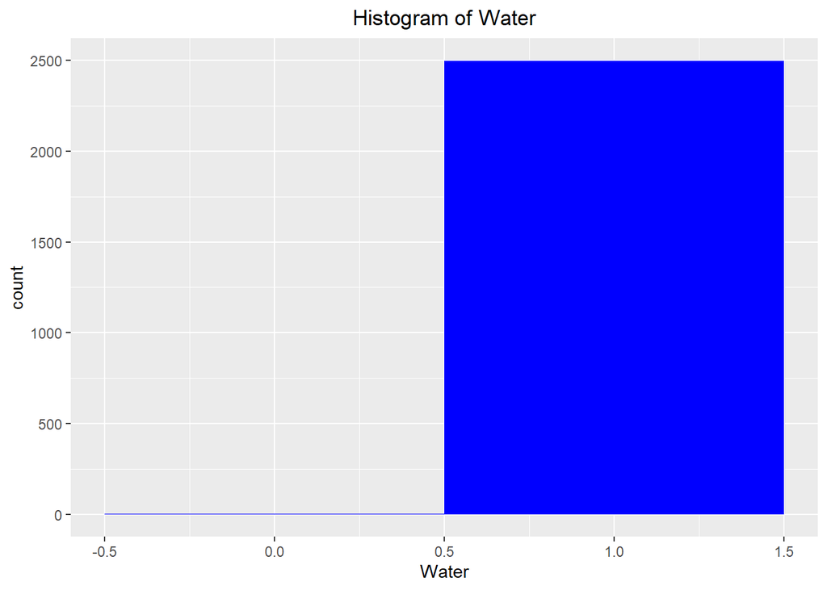

```r
ggplot(test_data, aes(x = Water)) +
  geom_histogram(binwidth = 1, fill = "blue") +
  ggtitle("Histogram of Water") + theme ( plot.title = element_text(hjust = 0.5))
```

### Question 8.1

```r
newdata <- test_data %>%
  mutate(
    transport_proximity = ifelse(BusyStreet == 1 | NearRail == 1, 1, 0),
    not_renovated = ifelse(Year_Built == Year_Renov, TRUE, FALSE)
  )
```

### Question 8.2

```r
sum(newdata$transport_proximity)
```

```
## [1] 290
```

### Question 8.3

```r
sum(!newdata$not_renovated)
```

```
## [1] 1158
```

### Question 8.4

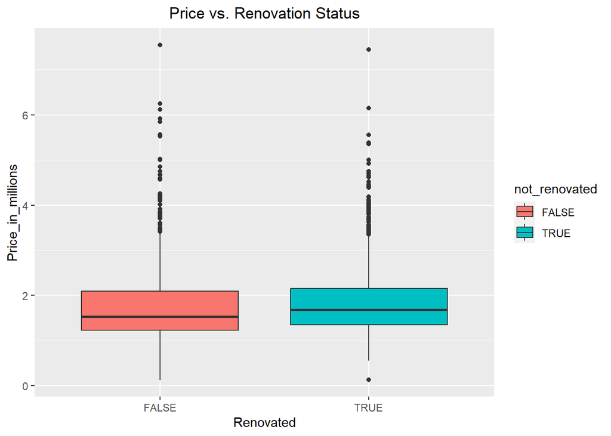

```r
newdata$Price_in_millions <- newdata$Price / 1e6
ggplot(newdata, aes(x = not_renovated, y = Price_in_millions, fill = not_renovated)) +
  geom_boxplot() +
  labs(x = "Renovated", y = "Price_in_millions") +
  ggtitle("Price vs. Renovation Status") + theme(plot.title = element_text(hjust = 0.5))
```

### Question 9

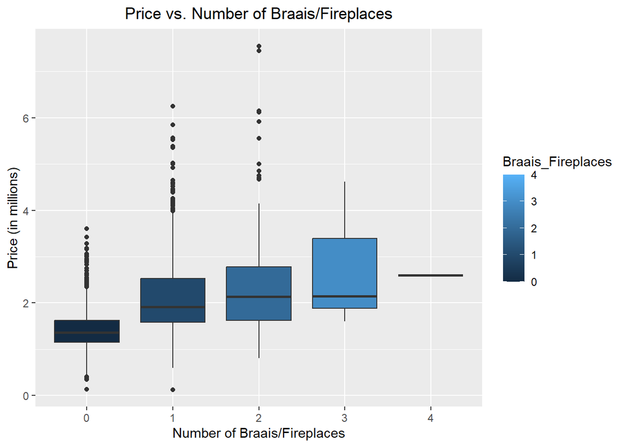

```r
# Boxplot for properties with different numbers of braais/fireplaces
test_data$Price_in_millions <- test_data$Price / 1e6
ggplot(test_data, aes(x = as.factor(Braais_Fireplaces), y = Price_in_millions, fill = Braais_Fireplaces)) +
  geom_boxplot() +
  labs(x = "Number of Braais/Fireplaces", y = "Price (in millions)") +
  ggtitle("Price vs. Number of Braais/Fireplaces") +
  theme(plot.title = element_text(hjust = 0.5))
```

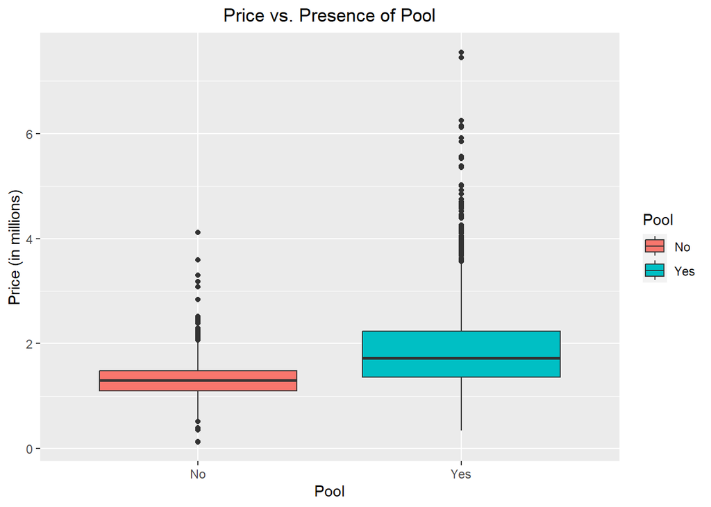

```r
test_data$Price_in_millions <- test_data$Price / 1e6
ggplot(test_data, aes(x = Pool, y = Price_in_millions, fill = Pool)) +
  geom_boxplot() +
  labs(x = "Pool", y = "Price (in millions)") +
  ggtitle("Price vs. Presence of Pool") +
  theme(plot.title = element_text(hjust = 0.5))
```

##### Looking at the boxplot, it shows that the median price of the properties sold with pools had a greater median price than the properies that did not have pools, this was also significantly greater. This gives the impression that having pools increases the property price by a significant amount. Furthermore, even the outliers for the properties with pools boasts a greater amount of money compared to properties without a pool.

#### Question 10

```r
test_data$Date_sold <- make_date(year = test_data$Year_sold, month = test_data$Month_sold)
#Citation: https://datacornering.com/how-to-join-year-month-and-day-into-a-date-in-r/#:~:text=The%20easiest%20way%20to%20combine,make_date%20from%20the%20lubridate%20package.&text=In%20this%20scenario%2C%20if%20you,day%20number%20column%20with%201.
```

### Question 11

#### Question 11.1

##### I believe the **Area** is necessary to consider when predicting house prices. I believe that the rank of highest sold property to lowest sold property would be:

1. Residential areas (as everyone needs a home so there will always be a market there)
2. Commercial (since businesses keep the economy afloat, and the rates on a building are not cheap. However, this would depend on the city/town as smaller towns would not have a big business hub) 3.Industrial properties
3. Agricultural properties (the upkeep of a farm is quite tedious and I do not believe most people would want to incur this cost unless they had the resources and the skill. Furthermore, it is quite risky and unstable to buy such a property as it is dependent on factors out of one’s control, weather for example and no two seasons are the same)

##### Furthermore, the **size of the property** could be a factor that contributes to prices. I assume expensive properties are bigger and smaller properties are cheaper.

##### The **type of property** (double storey, single storey, estate or duplex) could affect the prices. For example, assume that the estates would cost more as there is added security and estate prices to upkeep the estate as compared to the duplexes and in the same way. I predict that the rank of most expensive to least expensive properties sold would go as follows:

1. Double storey properties
2. Single storey properties
3. Estate properties
4. Duplex properties

##### The **condition** of the properties may affect the price of the propery. I believe that a well kept place, in good condition will be more expensive than a place that is not in good condition. Thus, properties with rankingings closer to 10 would be more appealing to a buyer, thus more expensive and properties closer to 1 would be less attractive to any buyer and be sold for less

##### Lastly, I believe that the **year built** will affect the price. I assume that the older the house, the less modern/appealing and I suspect that customers will not want to buy houses that are not modern

#### Question 11.2

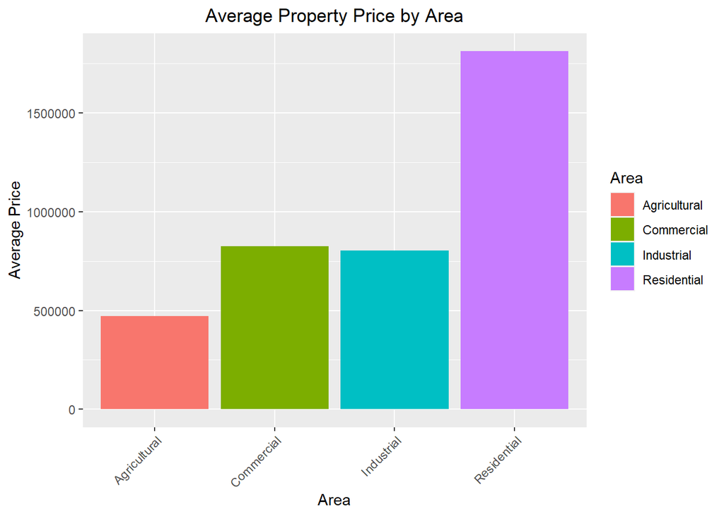

```r
test_data%>%
  group_by(Area) %>%
  summarise(Average_price = mean(Price)) %>%
  ggplot(aes(x = Area, y = Average_price, fill = Area)) +
  geom_bar(stat = "identity") +
  theme(axis.text.x = element_text(angle = 45, hjust = 1)) +
  labs(title = "Average Property Price by Area", x = "Area", y = "Average Price") + theme(plot.title = element_text(hjust = 0.5))
```

##### The results coincide with the my supposition in question 11.1. This is shown in the fact that the count for average prices for residential areas is the highest bar on the chart.I believe this supports my stance that people will always need houses and therefore housing will count a lot.Furthermore, commercial properties is second highest sold, then indiustrial then agricultural.

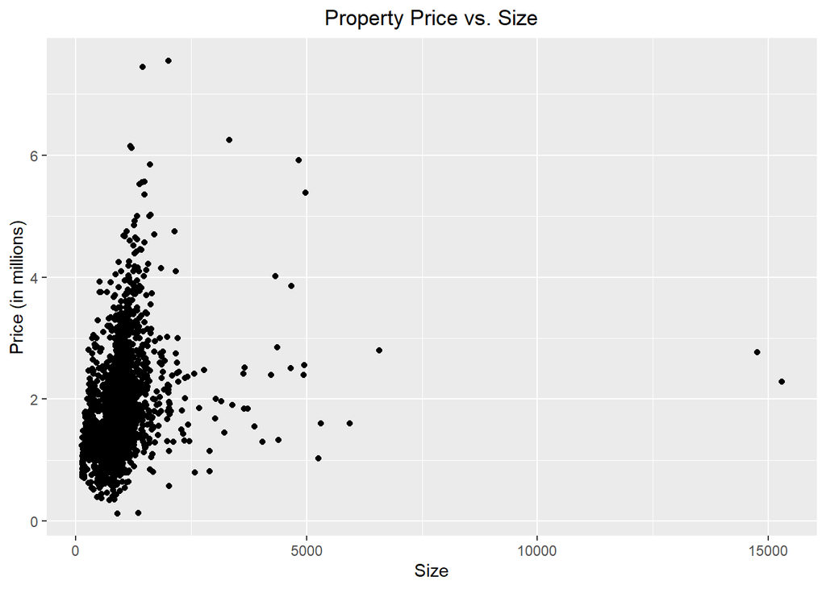

```r
ggplot(test_data, aes(x = Size, y = Price_in_millions)) +
  geom_point() +
  labs(title = "Property Price vs. Size", x = "Size", y = "Price (in millions)") + theme(plot.title = element_text(hjust = 0.5))
```

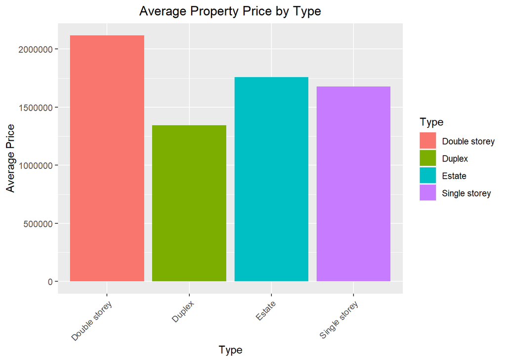

```r
test_data %>%
 group_by(Type) %>%
  summarise(Average_price = mean(Price)) %>%
  ggplot(aes(x = Type, y = Average_price, fill = Type)) +
  geom_bar(stat = "identity") +
  theme(axis.text.x = element_text(angle = 45, hjust = 1)) + theme(plot.title = element_text(hjust = 0.5)) +
  labs(title = "Average Property Price by Type", x = "Type", y = "Average Price")
```

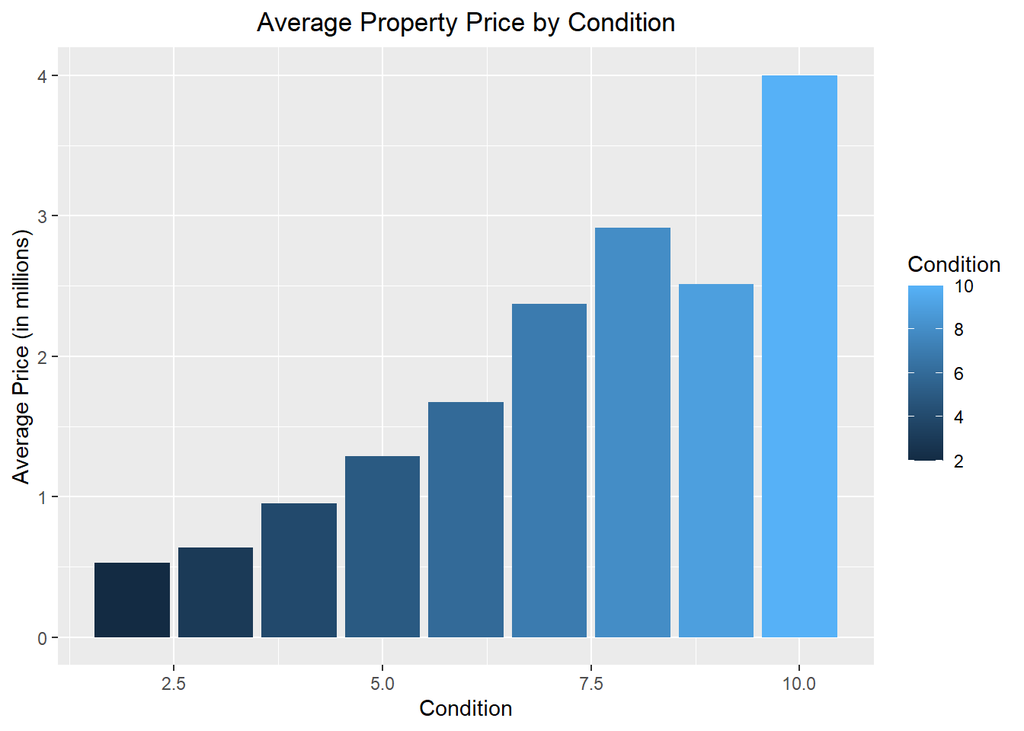

```r
test_data$Price_in_millions <- test_data$Price / 1e6
test_data %>%
  group_by(Condition) %>%
  summarise(Average_price = mean(Price_in_millions)) %>%
  ggplot(aes(x = Condition, y = Average_price, fill = Condition)) +
  geom_bar(stat = "identity") + theme(plot.title = element_text(hjust = 0.5)) +
  labs(title = "Average Property Price by Condition", x = "Condition", y = "Average Price (in millions)")
```

##### The general trend of this histogram is that the better the condition, the more expensive the property, this confirms my original hypothesis. There seems to be a dip between 7.5 and 10.0, this could be that the properties in that area were in an unfavourable area or they were not renovated or have been older houses.

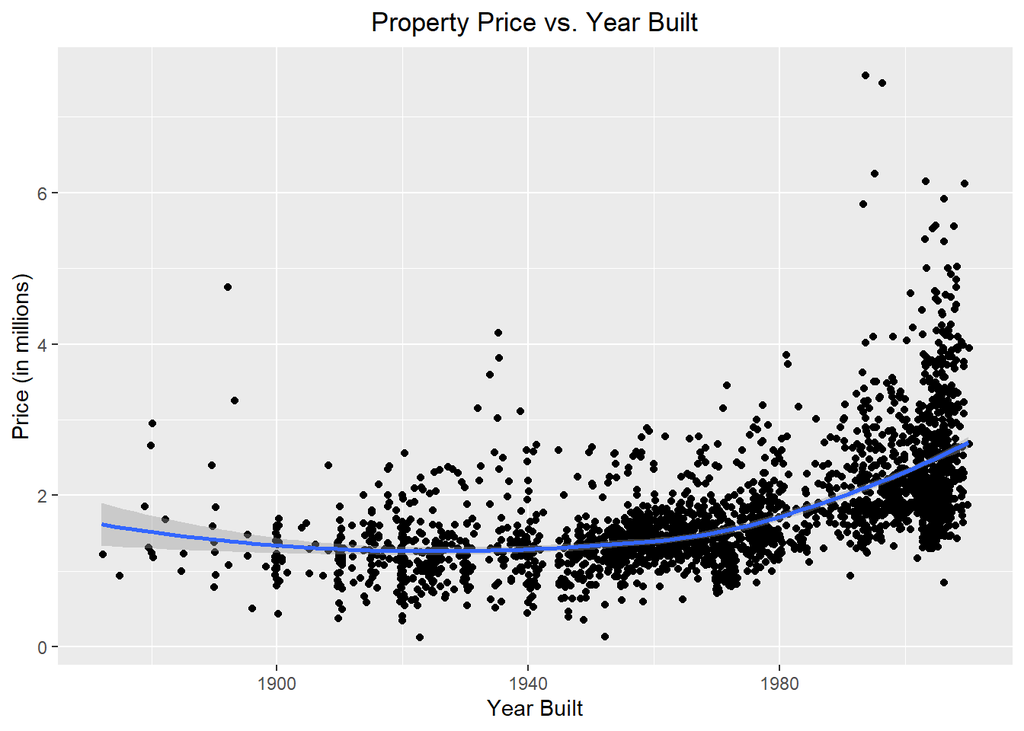

```r
test_data$Price_in_millions <- test_data$Price / 1e6

ggplot(test_data, aes(x = Year_Built, y = Price_in_millions)) +
  geom_point(position = "jitter") +
  theme(plot.title = element_text(hjust = 0.5)) + geom_smooth(formula = y ~ x, method = "loess") +
  labs(title = "Property Price vs. Year Built", x = "Year Built", y = "Price (in millions)")
```

```r
#Citation: https://stackoverflow.com/questions/66164964/how-to-turn-off-the-message-geom-smooth-using-method-loess-and-formula
```

##### The plot corresponds with my suspision as the smooth curve shows that the older houses sold for less money. The newer houses sold for more. This also shows because the points are more dense in the latter years.

### Question 12

#### Question 12.1

```r
formula<- Price_cat ~ Area + Type + Size + Corner + Bathrooms + Bedrooms + KitchenCondition + Braais_Fireplaces + Garages + Driveway + Pool


tree_model <- tree(formula, data = test_data)

summary(tree_model)
```

```
##
## Classification tree:
## tree(formula = formula, data = test_data)
## Variables actually used in tree construction:
## [1] "Garages"           "Size"              "Bathrooms"
## [4] "Braais_Fireplaces"
## Number of terminal nodes:  10
## Residual mean deviance:  1.276 = 3175 / 2489
## Misclassification error rate: 0.3025 = 756 / 2499
```

#### Question 12.2

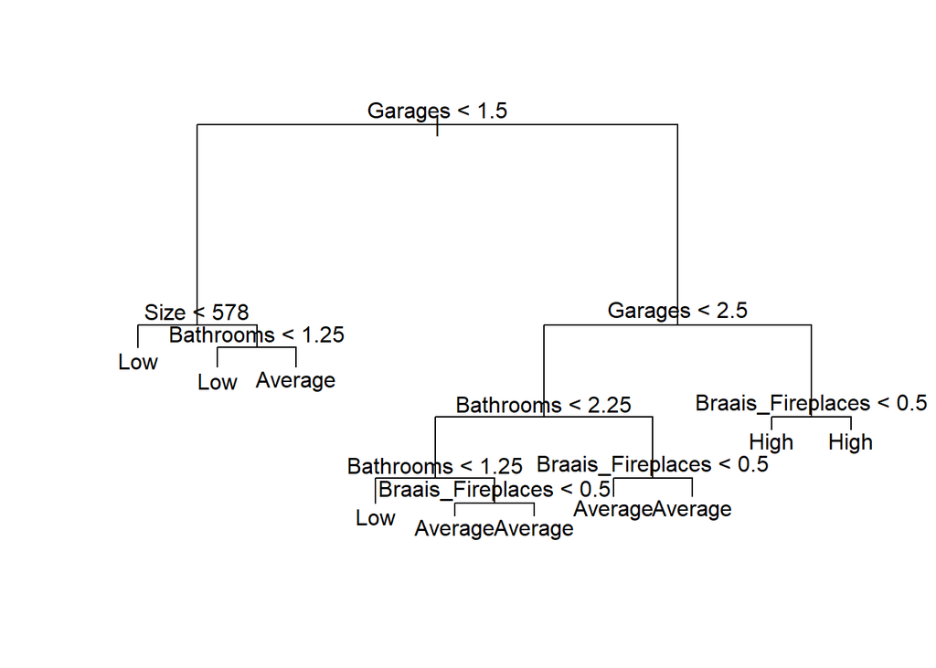

```r
plot(tree_model)
text(tree_model)
```